# condir: Examples

Angelos-Miltiadis Krypotos"

2017-02-15

### Condir

Below we provide two basic examples that use the R package *condir*. The first example regards data coming from a single group, and the second example data coming from two groups. More details about the package condir are described in the paper by Krypotos, A.-M., Klugkist, K., and Engelhard, I. M. (submitted). Bayesian Hypothesis Testing for Human Threat Conditioning Research: An introduction and the condir R package.

### Installation

To install condir, you first need to install and load the devtools package. This is done as follows.

```r
install.packages ("devtools")
library(devtools)
```

Now, the condir package can be installed by simply typing the following command in the R console.

```r
install_github(repo = "AngelosPsy/condir")
```

For loading condir, use the line below. Please note that for using condir, you have to load it at every new R session.

```r
library(condir)
```

### One group example

Here we show a single group example. Specifically, we first simulate data from a normal distribution for two stimuli, the cs1 and the cs2.

```r
set.seed(100)
cs1 <- rnorm(50, 5, 5)
cs2 <- rnorm(50, 4.5, 5)
```

These data correspond to the conditioned responses during the presentation of each stimulus (i.e., the cs1 and the cs2). For comparing the two stimuli, we can use the csCompare function in condir as follow.

```r
tmp <- csCompare(cs1, cs2)
```

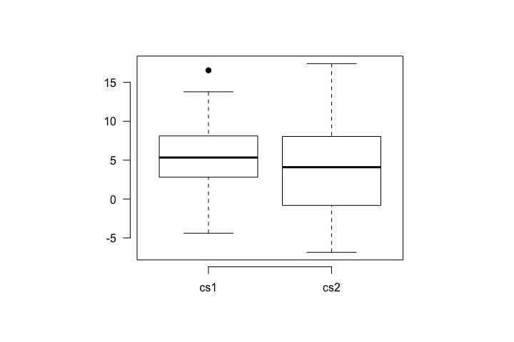

```r
tmp
```

```
$descriptives
    vars  n mean   sd   min   max range   se
cs1    1 50 5.41 4.10 -4.39 16.55 20.94 0.58
cs2    2 50 4.12 5.96 -6.86 17.41 24.27 0.84

$freq.results
         method alternative       WG1      WpG1 WG2 WpG2 null.value
1 Paired t-test   two.sided 0.9738392 0.3292263   0    0          0
         LCI      HCI t.statistic df   p.value    cohenD cohenDM   hedgesG
1 -0.3911855 2.963113    1.540853 49 0.1297863 0.2179096   small 0.2162376
  hedgesGM
1    small

$bayes.results
   LNI HNI rscale      bf10     bf01    propError
1 -Inf Inf  0.707 0.4640282 2.155041 3.081811e-08

attr(,"class")
[1] "csCompare"
```

The data can be plotted with the csPlot function.

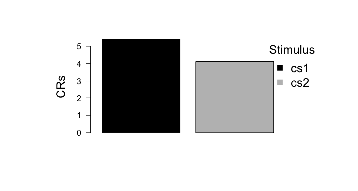

```r
csPlot(cs1, cs2, ylab = "CRs")
```

In order to make a basic report of the data, we use the csReport function.

```r
csReport(tmp)
```

```
We performed a two sided paired t-test. The results are t (49) = 1.541, p  =  0.13, Cohen's d = 0.218 (small effect size).
We performed a two sided Bayesian t-test, with a Cauchy prior, with its width set to 0.707. The BF01 was: BF01(0.707)  =  2.155. The BF10 was: BF10(0.707)  =  0.464.
```

Lastly, the csSensitivity function can be used for a sensitivity analysis, with the csRobustnessPlot function plotting the results.

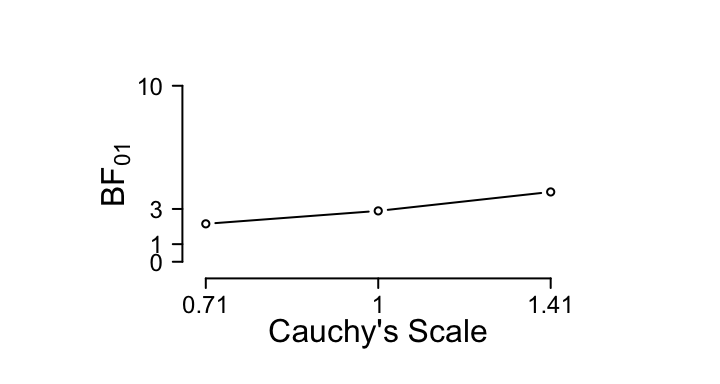

```r
tmp <- csSensitivity(cs1, cs2)
csRobustnessPlot(cs1, cs2, BF01 = TRUE)
```

The results are now reported with the csReport function.

```r
csReport(csSensitivityObj = tmp)
```

```
We performed a Sensitivity Analysis using the scaling factors: 0.707, 1, 1.41. The results for BF01 were: BF01(0.707)  =  2.155, BF01(1)  =  2.89, BF01(1.41)  =  3.956 respectively. The results for BF10 were: BF10(0.707)  =  0.464, BF10(1)  =  0.346, BF10(1.41)  =  0.253 respectively.
```

### Two groups example

The same steps as above are used for the two group example. The only difference is that we now have to define the group allocation by using the group argument – see the first line below. Apart from that, the code is the same as in the example above. That is why we provide the code for this example in a single chunk of code.

```r
group <- rep(1:2, 25)
tmp <- csCompare(cs1, cs2, group = group)
```

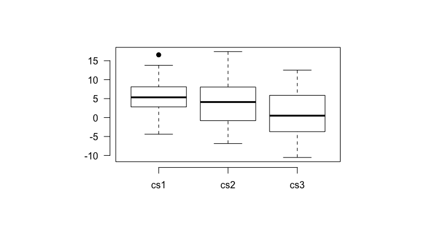

```r
tmp
```

```
$descriptives
$descriptives$`1`
    vars  n mean   sd    min   max range   se
cs1    1 25 3.32 2.80  -3.88 10.33 14.21 0.56
cs2    2 25 3.07 5.15  -6.86 13.14 20.00 1.03
cs3    3 25 0.24 5.58 -10.53 12.44 22.98 1.12

$descriptives$`2`
    vars  n mean   sd   min   max range   se
cs1    1 25 7.50 4.16 -4.39 16.55 20.94 0.83
cs2    2 25 5.17 6.61 -5.87 17.41 23.28 1.32
cs3    3 25 2.33 6.14 -8.71 12.51 21.22 1.23


$freq.results
                   method alternative       WG1      WpG1      WG2
1 Welch Two Sample t-test   two.sided 0.9786503 0.8571079 0.945581
       WpG2 null.value       LCI      HCI t.statistic       df   p.value
1 0.1989623          0 -5.421001 1.253531   -1.255701 47.57035 0.2153574
     cohenD cohenDM   hedgesG hedgesGM
1 0.2514526   small 0.2495233    small

$bayes.results
   LNI HNI rscale      bf10     bf01    propError
1 -Inf Inf  0.707 0.5379827 1.858796 0.0002218691

attr(,"class")
[1] "csCompare"
```

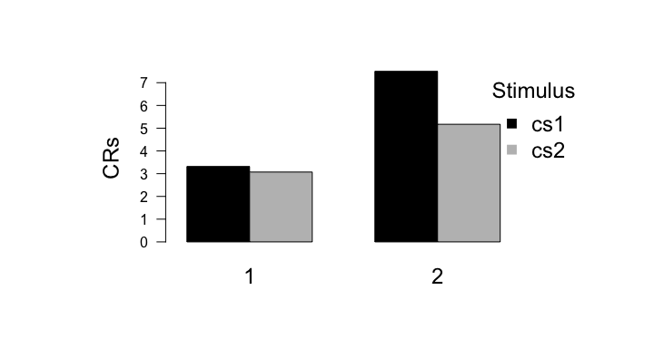

```r
csPlot(cs1, cs2, group = group, ylab = "CRs")
```

```r
csReport(csCompareObj = tmp)
```

```
We performed a two sided Welch two sample t-test. The results are t (47.57) = -1.256, p  =  0.215, Cohen's d = 0.251 (small effect size).
We performed a two sided Bayesian t-test, with a Cauchy prior, with its width set to 0.707. The BF01 was: BF01(0.707)  =  1.859. The BF10 was: BF10(0.707)  =  0.538.
```

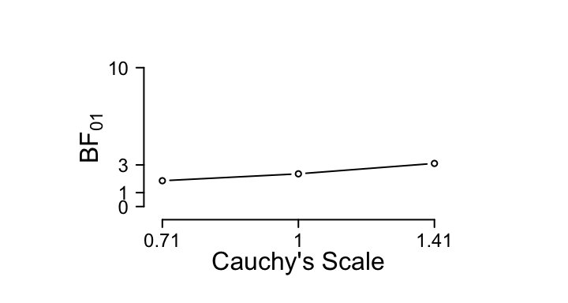

```r
tmp <- csSensitivity(cs1, cs2)
csRobustnessPlot(cs1, cs2, group, BF01 = TRUE)
```

```r
csReport(csSensitivityObj = tmp)
```

```
We performed a Sensitivity Analysis using the scaling factors: 0.707, 1, 1.41. The results for BF01 were: BF01(0.707)  =  2.155, BF01(1)  =  2.89, BF01(1.41)  =  3.956 respectively. The results for BF10 were: BF10(0.707)  =  0.464, BF10(1)  =  0.346, BF10(1.41)  =  0.253 respectively.
```